# Modele_liniowe

Jakub Ignatik

26 maja 2018

## Wprowadzenie

Celem projektu jest budowa modelu liniowego dla spalania samochodów. Model budowany jest na podstawie pliku “cars.csv”, który przedstawia spalanie, liczbę cylindrów, objętość silnika, moc w koniach mechanicznych, wagę, czas przyspieszenia, rok i miejsce produkcji dla danych modeli samochodów. Dane są podanie w systemie amerykańskim, dlatego zachodzić będzie konieczność przekształcenia ich na system europejski.  
**UWAGA!**Przeniosłem formatowanie danych do kolejnej części, aby we wprowadzeniu zająć się ogólnym wprowadzeniem oraz przedstawieniem hipotez. Zdecydowałem się też na umieszczenie kodu również w pliku html, żeby nie było potrzeby zaglądania do pliku źródłowego.  
**Hipotezy:** Co do przedziału ufności, myślę, że ten bootstrapowy będzie węższy, dla wszystkich parametrów modelu będzie mniejszy rozrzut. Spodziewam się też lepszego dopasowania do danych dla modelu bootstrapowego - będzie za tym iść większy współczynnik determinacji, lepsze kryteria informacyjne. Parametry nie powinny się zbytnio różnić (podejrzewam, że ten sam zbiór zostanie wskazany w obu metodach).  
Jeśli chodzi o to, które zmienne znajdą się w modelu, na samym wstępie mogę odrzucić nazwy samochodów. Nie będzie też na pewno albo pojemności silnika, albo liczby cylindrów (może ich obu), gdyż objętość silnika zależy od liczby cylindrów. Nie wydaje mi się też, żeby pochodzenie samochodu wpływało szczególnie na spalanie.

### Klasyczny model liniowy

Na samym początku załaduję biblioteki i wczytam ramkę danych, a następnie zamienię jednostki na system europejski (zostawiam przyspieszenie, ponieważ jest to nieznaczna różnica w wielkości) oraz usuwam nazwy samochodów (nie mają one znaczenia w modelu).

```r
library(stats)
library(tidyr)
library(ggplot2)
library(tibble)
library(lmtest)
```

```r
dane <- read.csv("cars.csv", dec=".",sep=",",header=TRUE)
#Zamiana spalania z mpg na l/100km
dane[1] = round(235.21/dane[1],2)
colnames(dane)[1] = "lnskm"
#Zamiana objętości silnika z cali^3 na cm^3
dane[3] = dane[3]*16.39
#Zamiana wagi z funtów na kilogramy
dane[5] = dane[5]*0.45
#Usunięcie nazw samochodów
dane[9] = NULL
```

Postanowiłem zamienić zmienną “origin” na zmienną zero-jedynkową, ponieważ przypisanie różnych mnożników do pochodzenia mogłoby zniekształcić parametr przy tej zmiennej.

```r
#1 - auto pochodzi z USA, 0 - z innego kraju
for (i in 1:314){
  if (dane[i,8] == 1)
    dane[i,9] = 1
  else
    dane[i,9] = 0
}

#1 - auto pochodzi z Europy, 0 - z innego kontynentu
for (i in 1:314){
  if (dane[i,8] == 2)
    dane[i,10] = 1
  else
    dane[i,10] = 0
}


#1 - auto pochodzi z Japonii, 0 - z innego kraju
for (i in 1:314){
  if (dane[i,8] == 3)
    dane[i,11] = 1
  else
    dane[i,11] = 0
}

dane[8] <- dane[9]
colnames(dane)[8] = "USA"

dane[9] <- dane[10]
colnames(dane)[9] = "Europe"

dane[10] <- dane[11]
colnames(dane)[10] = "Japan"

dane[11] <- NULL
```

Do wstępnej redukcji zmiennych posłuży mi współczynnik zmienności, badający zróżnicowanie cechy.

```r
for (i in 1:10){
  print(paste(colnames(dane)[i], ": ", (sd(dane[,i])/mean(dane[,i]))*100, sep=''))
}
```

```
## [1] "lnskm: 34.8378462542258"
## [1] "cylinders: 31.1658991745384"
## [1] "displacement: 54.0540475308696"
## [1] "horsepower: 36.4704855612602"
## [1] "weight: 28.8995705312448"
## [1] "acceleration: 17.655749836688"
## [1] "year: 4.77415968105776"
## [1] "USA: 80.3763957060896"
## [1] "Europe: 217.350774739125"
## [1] "Japan: 190.504725312714"
```

Zmienna “year” jest statystycznie nieistotna, ponieważ posiada mniej niż 10% zmienności. Należy zatem usunąć ją z modelu.

```r
dd <- c("lnskm","cylinders","displacement","horsepower","weight","acceleration","USA","Europe","Japan")
dane <- dane[dd]
```

Aby lepiej zobrazować zależności w modelu, posłużę się teraz macierzą korelacji.

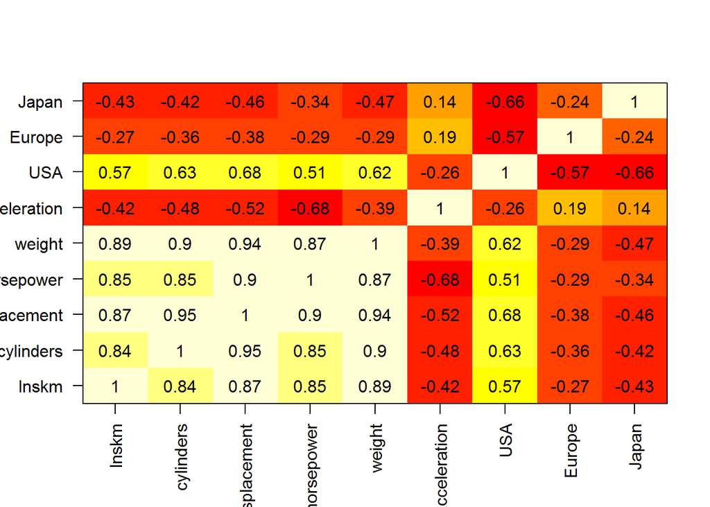

```r
COR <- cor(dane[,1:9])
image(x=seq(nrow(COR)), y=seq(ncol(COR)), z=cor(dane[,1:9]), axes=F, xlab="", ylab="")
text(expand.grid(x=seq(dim(COR)[1]), y=seq(dim(COR)[2])), labels=round(c(COR),2))
box()
axis(1, at=seq(nrow(COR)), labels = rownames(COR), las=2)
axis(2, at=seq(ncol(COR)), labels = colnames(COR), las=1)
```

```r
hellwig <- function( y, x, method="pearson")
{
  requireNamespace("utils")
  x <- as.data.frame(x)
  cm <- stats::cor(x, method=method) # korelacje wewnątrz zmiennych niezależnych
  cd <- stats::cor(x, y, method=method) # korelacje ze zmienną zależną
  # lista kombinacji zmiennych
  k <- sapply( seq(2, length(x)), function(i)
    utils::combn(length(x), i, simplify=FALSE) )
  k <- do.call("c", k)
  # liczenie indywidualnych wskaźników pojemności informacyjnych
  hfun <- function(v)
  {
    sapply(v, function(i) cd[i]^2 / sum(abs(cm[v,i])) )
  }
  #budowanie ramki danych dla zintegrowanych wskaźników pojemności informacyjnych
  h <- sapply(k, hfun)
  data.frame( k = sapply( k, paste, collapse="-"),
              h = sapply(h, sum),
              stringsAsFactors=FALSE)
}
#metoda Hellwiga na badanym zbiorze
hh <- hellwig(dane[,1],dane[,2:9],method = "pearson")
#wskazanie kombinacji o największej pojemności informacyjnej
hh[which.max(hh[,2]),]
```

```
##      k         h
## 14 3-4 0.8183235
```

Dla wskazanej kombinacji zbuduję model liniowy i sprawdzę, czy nie ma w nim katalizatorów:

```r
katalizator <- function(y, xlist){
  k = length(xlist)
  ramka <- data.frame(y,xlist)

  #tworzę macierze R i R0
  R <- matrix(data=0,nrow = k, ncol = k)
  R0 <- matrix(data=0,nrow = k, ncol = 1)
  for (i in 1:k){
    COR <- cor(ramka$y,ramka[i+1])
    R0[i,1]=COR
    for (j in 1:k){
      COR <- cor(ramka[i+1],ramka[j+1])
      R[i,j]= COR
    }
  }

  #macierz "przejscie" pozwoli na stworzenie regularnego R0 poprzez określenie     kolejności zmiennych w regularnym R0
  przejscie <- matrix(data=0, nrow = k, ncol = 2)
  R0_regularne <- matrix(data=sort(abs(R0)),nrow = k,ncol = 1)
  for (i in 1:k){
    for (j in 1:k){
      if (R0_regularne[i,1] == abs(R0[j,1])){
        przejscie[i,1]=j
        if (R0[j,1]>0){
          przejscie[j,2]=1
        }
        else{
          przejscie[j,2]=-1
        }
      }
    }
  }

  #tworzenie regularnego R
  R_regularne <- R
  for (i in 1:k){
    i = przejscie[i,1]
    for (j in 1:k){
      R_regularne[i,j]=przejscie[przejscie[j,1],2]*przejscie[przejscie[i,1],2]*R[przejscie[j,1],przejscie[i,1]]
      R_regularne[j,i]=R_regularne[i,j]
    }
  }

  katalizator <- 0

  #sprawdzanie macierzy R_regularne pod kątem obecności zmiennych-katalizatoróW
  for (i in 1:k){
    for (j in 1:k){
      a <- R_regularne[i,j]
      if ((i<j) & (a < 0 | a > (R0_regularne[i,1]/R0_regularne[j,1]))){
        katalizator = a
      }
    }
  }
  zz <- 0

  for (i in 1:k){
    for (j in 1:k){
      numer <- przejscie[i,1]
      if ((R[i,j] == katalizator | abs(R[i,j]) == katalizator) & i<j){
        print("Numer zmiennej objaśniającej będącej katalizatorem:")
        print(numer)
        zz = zz+1
        print("Wartość katalizatora:")
        print(katalizator)
      }
    }
  }
  if (zz == 0){
    print("Brak katalizatorów")
  }
}

y <- dane$lnskm
lista <- list(dane$horsepower,dane$weight)
katalizator(y,lista)
```

```
## [1] "Brak katalizatorów"
```

W modelu nie występuje zmienna-katalizator, czyli współczynnik determinacji nie jest zawyżany.  
Zbuduję teraz model dla wskazanej przez Helwiga kombinacji i sprawdzę jego statystyczną istotność oraz wartość R^2.

```r
model <- lm(lnskm ~ horsepower+weight, data = dane)
summary(model)
```

```
##
## Call:
## lm(formula = lnskm ~ horsepower + weight, data = dane)
##
## Residuals:
##     Min      1Q  Median      3Q     Max
## -4.7227 -0.9887  0.0339  0.8502  7.1032
##
## Coefficients:
##               Estimate Std. Error t value Pr(>|t|)
## (Intercept) -0.5547713  0.3384429  -1.639    0.102
## horsepower   0.0319704  0.0049361   6.477 3.65e-10 ***
## weight       0.0062981  0.0004868  12.938  < 2e-16 ***
## ---
## Signif. codes:  0 '***' 0.001 '**' 0.01 '*' 0.05 '.' 0.1 ' ' 1
##
## Residual standard error: 1.644 on 311 degrees of freedom
## Multiple R-squared:  0.8242, Adjusted R-squared:  0.8231
## F-statistic:   729 on 2 and 311 DF,  p-value: < 2.2e-16
```

Współczynnik determinacji jest wysoki, nie ma do niego zastrzeżeń. Co do ważności parametrów, model jako całość jest statystycznie istotny (wykazała to statystyka F). Kiedy jednak spojrzy się na istotność poszczególnych parametrów, okazuje się, że stała jest nieistotna statystycznie. Przeprowadzę teraz Partial F-test, który wykaże, czy po odjęciu z modelu stałej nie zwiększy się suma błędów podniesionych do kwadratu (SSE).

```r
#H0: Brak statystycznej istotnej różnicy w SSE w obu modelach.
#H1: Model "pełny" ma statystycznie mniejsze SSE niż model zredukowany.
model_zredukowany <- lm(lnskm ~ 0+horsepower+weight, data = dane)
anova(model_zredukowany,model)
```

```
## Analysis of Variance Table
##
## Model 1: lnskm ~ 0 + horsepower + weight
## Model 2: lnskm ~ horsepower + weight
##   Res.Df    RSS Df Sum of Sq      F Pr(>F)
## 1    312 847.87
## 2    311 840.61  1    7.2626 2.6869 0.1022
```

Jak widać, nie ma podstaw do odrzucenia hipotezy H0, czyli model zredukowany nie zwiększa SSE. Należy zatem pozostać na zredukowanym modelu.

```r
model <- model_zredukowany
summary(model)
```

```
##
## Call:
## lm(formula = lnskm ~ 0 + horsepower + weight, data = dane)
##
## Residuals:
##     Min      1Q  Median      3Q     Max
## -4.8113 -1.1208 -0.0257  0.8016  7.3327
##
## Coefficients:
##             Estimate Std. Error t value Pr(>|t|)
## horsepower 0.0331750  0.0048942   6.778 6.08e-11 ***
## weight     0.0058207  0.0003911  14.883  < 2e-16 ***
## ---
## Signif. codes:  0 '***' 0.001 '**' 0.01 '*' 0.05 '.' 0.1 ' ' 1
##
## Residual standard error: 1.648 on 312 degrees of freedom
## Multiple R-squared:  0.9809, Adjusted R-squared:  0.9807
## F-statistic:  7995 on 2 and 312 DF,  p-value: < 2.2e-16
```

Nowy model posiada współczynnik determinacji bliski 1, co bardzo dobrze świadczy o modelu. Należy teraz zbadać, czy w modelu nie występuje współliniowość. W tym celu utworzę dwa nowe modele i sprawdzę, czy ich współczynniki determinacji nie przekraczają wartości 0.9.

```r
#waga wyjaśniana za pomocą koni
model_wsp <- lm(weight ~ 0+horsepower, data = dane)
summary(model_wsp)$r.squared
```

```
## [1] 0.9708424
```

```r
#konie wyjaśnione za pomocą wagi
model_wsp2 <- lm(horsepower ~ 0+weight, data = dane)
summary(model_wsp2)$r.squared
```

```
## [1] 0.9708424
```

Okazuje się, że w modelu występuje współliniowość. W obu przypadkach współczynnik determinacji przekroczył wartość 0.9. Gdyby w modelu była stała, problem nie wystąpiłby, jednak stała nie byłaby statystycznie istotna. Można zauważyć, że z racji dużych korelacji między zmiennymi objaśniającymi trudno jest uniknąć takiego problemu, dlatego też postanowiłem nie działać w kierunku likwidacji współliniowości. Przetestuję teraz, czy spełnione są pozostałe założenia dobrego modelu liniowego.

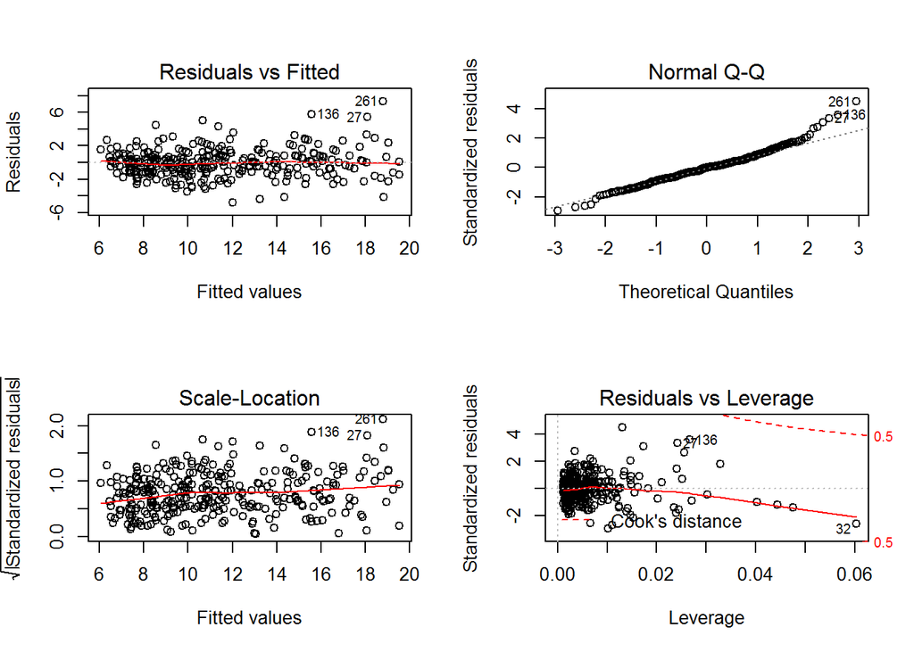

```r
par(mfrow=c(2,2))
plot(model)
```

Na pierwszym wykresie, gdzie skonfrontowane są reszty modelu z jego dopasowaniem, można zauważyć płaską, czerwoną linię, co świadczy o spełnieniu założenia dotyczącego liniowości modelu. Punkty tworzą chmurę, nie widać, aby na początku czy końcu oddalały się od linii, co świadczy o tym, że model nie jest heteroskedastyczny.  
Na wykresie Q-Q (kwantyl-kwantyl) widać, że punkty tworzą linię prostą (z wyjątkiem samego początku i końca - może być za mało danych w modelu), co świadczy o tym, że spełnione jest założenie o normalności reszt.  
Na trzecim wykresie, Scale-Location, widać dość płaską, czerwoną linię, co potwierdza homoskedastyczność modelu.  
Na ostatnim z czterech wykresów, Residuals vs Leverage, przedstawiona pokazała odległość Cooka, czyli miara stopnia zmiany współczynników regresji, gdyby dany przypadek pominąć w obliczeniach współczynników (miara wpływu poszczególnych obserwacji na prostą regresji). Gdyby któryś przypadek znalazł się za linią Cooka, należałoby go wykluczyć z modelu, aby był on bardziej dopasowany. W tym przypadku jednak wszystko jest w porządku, takie punkty nie istnieją.

Zbadam teraz, czy w modelu nie występuje autokorelacja.

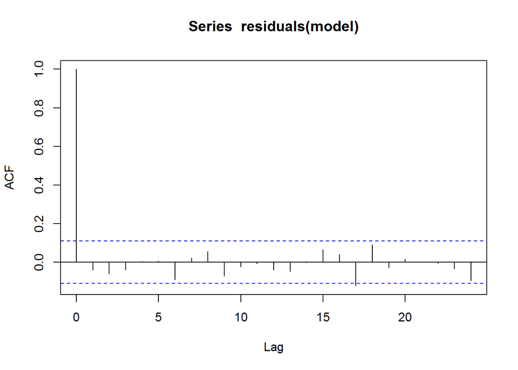

```r
acf(residuals(model))
```

### Model bootstrapowy

Początek jest taki sam, jak przy metodzie klasycznej: zamieniam jednostki, wyrzucam nazwy samochodów, przekształcam zmienną “origin” i wyrzucam zmienną “year”. Teraz zweryfikuję, które zmienne są statystycznie istotne. Powinno to przebiegać stopniowo, bez wyrzucania wszystkich zmiennych nieistotnych jednocześnie, jednak nie posiadam pętli, która by to wykonała. Przy wyrzuceniu wszystkich zmiennych nieistotnych naraz wyszedł ten sam zbiór, co przy redukowaniu krok po kroku, więc zaprezentuję kod “przyspieszony”.

```r
N<- length(dane[,1])
#pierwszy zbiór jest dla stałej, a dalsze dla kolejnych zmiennych objaśniających
zbior <- rep(NA, 10000)
zbior2 <- rep(NA, 10000)
zbior3 <- rep(NA, 10000)
zbior4 <- rep(NA, 10000)
zbior5 <- rep(NA, 10000)
zbior6 <- rep(NA, 10000)
zbior7 <- rep(NA, 10000)
zbior8 <- rep(NA, 10000)
zbior9 <- rep(NA, 10000)

for (i in 1:10000){
  idx <- sample(1:N, N, replace = TRUE)
  nowe_dane <- dane[idx,]
  model_nowy <- lm(lnskm ~ cylinders+displacement+horsepower+weight+acceleration+USA+Europe+Japan, data = nowe_dane)
  zbior[i] <- coef(model_nowy)[1]
  zbior2[i] <- coef(model_nowy)[2]
  zbior3[i] <- coef(model_nowy)[3]
  zbior4[i] <- coef(model_nowy)[4]
  zbior5[i] <- coef(model_nowy)[5]
  zbior6[i] <- coef(model_nowy)[6]
  zbior7[i] <- coef(model_nowy)[7]
  zbior8[i] <- coef(model_nowy)[8]
  zbior9[i] <- coef(model_nowy)[9]
}

#przedziałY ufności dla parametrów
quantile(zbior, c(0.025, 0.975))
```

```
##       2.5%      97.5%
## -6.7224261  0.3515134
```

```r
quantile(zbior2, c(0.025, 0.975))
```

```
##       2.5%      97.5%
## -0.1344396  0.6462838
```

```r
quantile(zbior3, c(0.025, 0.975))
```

```
##          2.5%         97.5%
## -0.0007584298  0.0007186319
```

```r
quantile(zbior4, c(0.025, 0.975))
```

```
##       2.5%      97.5%
## 0.01858124 0.07082222
```

```r
quantile(zbior5, c(0.025, 0.975))
```

```
##        2.5%       97.5%
## 0.002444324 0.006392897
```

```r
quantile(zbior6, c(0.025, 0.975))
```

```
##        2.5%       97.5%
## -0.01787802  0.30107363
```

```r
quantile(zbior7, c(0.025, 0.975))
```

```
##       2.5%      97.5%
## -0.0871320  0.9936872
```

```r
quantile(zbior8, c(0.025, 0.975))
```

```
##       2.5%      97.5%
## -0.1751718  0.9105811
```

```r
quantile(zbior9, c(0.025, 0.975))
```

[output not shown]

```r
#współczynnik determinacji R^2
r2 <- rep(NA, 10000)
#skorygowany współczynnik determinacji R^2
adjr2 <- rep(NA, 10000)
#AIC
aic <- rep(NA, 10000)
#BIC
bic <- rep(NA, 10000)
#zbiorek jest dla parametrów przy zmiennej "horsepower"
zbiorek <- rep(NA, 10000)
#zbiorek2 jest dla parametrów przy zmiennej "weight"
zbiorek2 <- rep(NA, 10000)

for (i in 1:10000){
  idx <- sample(1:N, N, replace = TRUE)
  nowe_dane <- dane[idx,]
  model_nowy <- lm(lnskm ~ 0+horsepower+weight, data = nowe_dane)
  r2[i] <- summary(model_nowy)$r.squared
  adjr2[i] <- summary(model_nowy)$r.squared
  aic[i] <- AIC(model_nowy)
  bic[i] <- BIC(model_nowy)
  zbiorek[i] <- coef(model_nowy)[1]
  zbiorek2[i] <- coef(model_nowy)[2]
}
```

Porównam teraz parametry modelu klasycznego z modelem bootstrapowym:

```r
klasyk <- c(coef(model)[1],coef(model)[2],summary(model)$r.squared,summary(model)$adj.r.squared,AIC(model),BIC(model))
boot <- c(mean(zbiorek),mean(zbiorek2),mean(r2),mean(adjr2),mean(aic),mean(bic))
ramka <- format(data.frame(klasyk,boot),scientific = FALSE)
colnames(ramka) <- c("Klasyk","Bootstrap")
rownames(ramka) <- c("Horsepower","Weight","R^2","SKorygowane R^2", "AIC", "BIC")
ramka
```

```
##                         Klasyk      Bootstrap
## Horsepower         0.033174983    0.033366893
## Weight             0.005820673    0.005805728
## R^2                0.980862347    0.981068551
## SKorygowane R^2    0.980739670    0.981068551
## AIC             1209.001490883 1203.729779705
## BIC             1220.249669841 1214.977958662
```

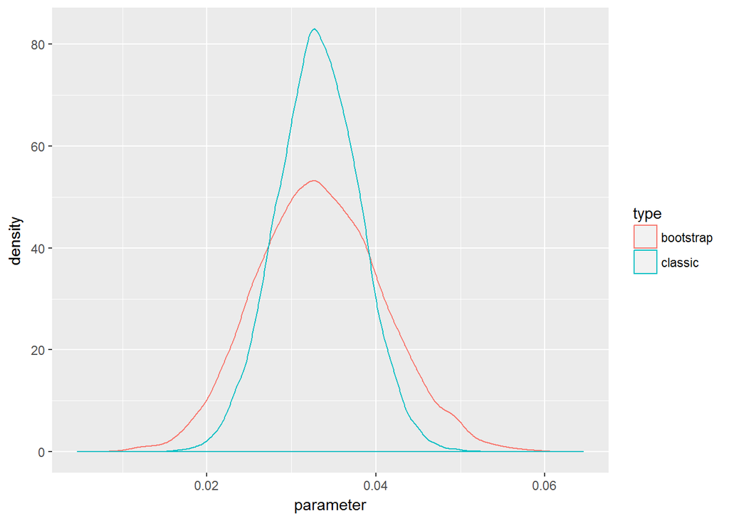

```r
coefs_model <- summary(model)$coefficients

set.seed(123)
wykres <- tibble(bootstrap = zbiorek,
                 classic =
                   coefs_model[1,1] +
                   rnorm(10^4)*coefs_model[1,2] ) %>%
  gather(type, parameter)


wykres %>%
  ggplot(aes(x = parameter, col = type)) +
  geom_density()
```

Jak widać na wykresie, przedział ufności dla zmiennej “horsepower” jest węższy i wyższy przy metodzie klasycznej. Spodziewałem się sytuacji odwrotnej. Parametry dla zmiennej “horsepower” okazały się mieć większy “rozrzut” dla metody bootstrapowej.

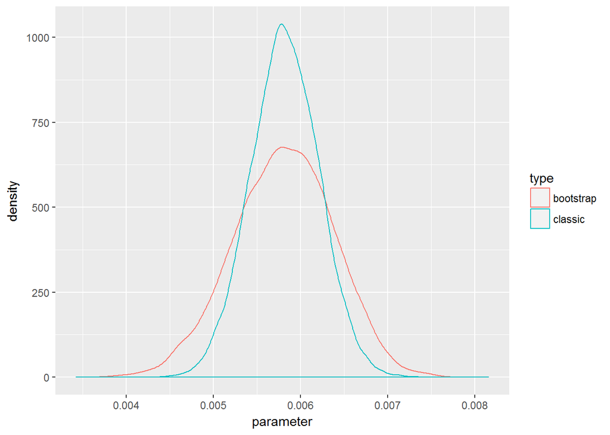

```r
set.seed(123)
wykres <- tibble(bootstrap = zbiorek2,
                 classic =
                   coefs_model[2,1] +
                   rnorm(10^4)*coefs_model[2,2] ) %>%
  gather(type, parameter)


wykres %>%
  ggplot(aes(x = parameter, col = type)) +
  geom_density()
```

Poza skalą, wykresy prezentują się tak samo jak w poprzednim przypadku. Tu również nie spełniło się moje podejrzenie, ponownie większy “rozrzut” jest dla metody boootstrapowej.

### Podsumowanie

Ostatecznie, w obu przypadkach, spalanie zależy od koni mechanicznych i wagi samochodu. Sprawdziły się moje hipotezy dotyczące braku zmiennej “displacement” lub/i “cylinders” oraz braku wpływu pochodzenia. Zostały spełnione założenia dotyczące normalności rozkładu reszt, heteroskedastyczności, liniowości modelu oraz autokorelacji.  
Model bootstrapowy okazał się być lepiej dopasowany do modelu, ale wiązać się to może z przeuczeniem modelu, choć różnica między dwoma modelami jest nieznaczna i może wynikać z wartości parametrów.  
Zaskoczenie stanowiły wykresy przedziałów ufności dla modeli - spodziewałem się odwrotnych rezultatów.